# Practice Code: Day 3

Author

Constantin Manuel Bosancianu

Published

July 31, 2019

# 1 Introduction

We start as yesterday, by loading a few needed packages, and by defining a few custom functions we use below.

```python
import pandas as pd
pd.set_option('display.precision', 2)
import numpy as np
import pyreadr as prr
import os
import random
from plotnine import *
import statsmodels.formula.api as sm1
import statsmodels.api as sm2
import statsmodels.stats.api as sms
import scipy as sp
import matplotlib.pyplot as plt
import itertools
```

```python
def regress(data, yvar, xvars):
    Y = data[yvar]
    X = data[xvars]
    X['intercept'] = 1.
    result = sm2.OLS(Y, X).fit()
    return pd.DataFrame(result.summary2().tables[1])

def fun_two_SD(x):
    return (x - np.mean(x, axis = 0)) / (2 * np.std(x))

def fun_cent_noSD(x):
     return x - np.mean(x)
```

# 2 Centering

So far, we have run models without centering any of the variables. Based on the lecture earlier, we now have the knowledge to start centering our predictors. Just a quick reminder: centering should always be done for predictors, irrespective of whether there is a cross-level interaction in the model or not:

- it will give a meaningful value to the intercept;
- it will speed up the ML-based estimation algorithm;
- more important, it will only estimate relationships between L1 predictors and the L1 outcome based on L1 variation, and not a mix of L1 and L2 variation.

Since this centering and standardization is done over and over again, it pays off to have a dedicated function for it: `fun_two_SD()` in the previous code chunk.

In my own applied work I use the Gelman method less often, as I find that some readers find it hard to switch between interpretations in the original scale and interpretations in SD-units. Additionally, I am typically not interested in assessing which variable has a stronger effect; if that is the case, I rely of predictions to show this. This is why I offer here a function only for centering: `fun_cent_noSD()` in the previous code chunk. You can use either one for your own purposes.

To keep things consistent with how Gelman and Hill discuss the topic, though, we will do centering and standardizing in this tutorial, though.

```python
result = prr.read_r("../02-data/01-ISSP.rds")
df_issp = result[None]

df_issp = df_issp[["cnt", "year", "country", "poleff", "female",
                   "age10", "educ", "urban", "incquart", "ti_cpi"]]
df_issp = df_issp.dropna()

df_dumm = pd.get_dummies(df_issp['incquart'], prefix = "inc")

frames = [df_issp, df_dumm]
df_issp = pd.concat(frames, axis = 1)
```

```python
df_grouped = df_issp.groupby("cnt")[["age10", "female", "educ",
          "urban", "inc_1", "inc_2",
          "inc_3", "inc_4"]].transform(lambda x: fun_two_SD(x))
df_grouped = df_grouped.rename({'age10': 'age10CWC',
                                'female': 'femCWC',
                                'educ': 'educCWC',
                                'urban': 'urbanCWC',
                                'inc_1': 'inc1CWC',
                                'inc_2': 'inc2CWC',
                                'inc_3': 'inc3CWC',
                                'inc_4': 'inc4CWC'},
                               axis = 1)

frames = [df_issp, df_grouped]
df_issp = pd.concat(frames, axis = 1)
```

Our L2 data was already supplied merged with L1 data, so it first needs to be aggregated back up at the country level, then centered, and then merged back in.

```python
df_agg = df_issp.groupby("cnt")["ti_cpi"].mean().reset_index()
df_agg['cpiCGM'] = fun_two_SD(df_agg['ti_cpi'])
df_agg = df_agg.drop(['ti_cpi'], axis = 1)
```

Finally, we merge `df_agg` with `df_issp` using country as a matching indicator.

```python
df_issp = df_issp.merge(df_agg, on = "cnt", how = "left")
```

If the group-mean centering worked OK, the mean of the variable after centering in each of the groups should be 0.[^1]

<sup>1</sup> We rely on a custom function to do these calculations, since it involves different operations applied to either single columns or two columns.

```python
def fun_agg(x):
    d = {}
    d['age_mean'] = x['age10'].mean()
    d['age_cwc_mean'] = x['age10CWC'].mean()
    d['age_corr'] = x[['age10', 'age10CWC']].corr().iloc[1, 0]
    return pd.Series(d, index=['age_mean', 'age_cwc_mean', 'age_corr'])

df_issp.groupby("cnt").apply(fun_agg).rename({'cnt': 'Country',
                                              'age_mean': 'Original version',
                                              'age_cwc_mean': 'Centered version',
                                              'age_corr': 'Correlation'}).to_html()
```

| cnt | age_mean | age_cwc_mean | age_corr |
| --- | --- | --- | --- |
| AT | 4.99 | 1.21e-17 | 1.0 |
| AU | 5.38 | 1.60e-16 | 1.0 |
| BE | 4.59 | 4.22e-17 | 1.0 |
| CH | 4.97 | 1.60e-16 | 1.0 |
| CL | 4.87 | 5.45e-18 | 1.0 |
| CZ | 5.26 | -2.27e-16 | 1.0 |
| DE | 4.96 | -5.77e-17 | 1.0 |
| DK | 4.79 | -7.83e-17 | 1.0 |
| EE | 4.49 | -4.29e-17 | 1.0 |
| ES | 4.99 | 1.64e-16 | 1.0 |
| FI | 4.73 | 2.59e-17 | 1.0 |
| FR | 5.14 | 1.55e-16 | 1.0 |
| GB | 5.24 | -1.25e-17 | 1.0 |
| GE | 4.85 | 2.39e-17 | 1.0 |
| HR | 4.60 | -1.11e-16 | 1.0 |
| IL | 4.98 | -1.45e-16 | 1.0 |
| IN | 4.04 | 2.03e-17 | 1.0 |
| IS | 4.83 | 8.49e-17 | 1.0 |
| JP | 5.32 | -5.80e-17 | 1.0 |
| KR | 4.53 | -1.76e-16 | 1.0 |
| LT | 5.05 | 4.70e-17 | 1.0 |
| NL | 5.49 | 2.23e-16 | 1.0 |
| NO | 4.99 | 1.93e-16 | 1.0 |
| NZ | 5.40 | -1.15e-16 | 1.0 |
| PH | 4.31 | 3.87e-17 | 1.0 |
| PL | 5.09 | 1.72e-16 | 1.0 |
| RU | 4.82 | 2.21e-16 | 1.0 |
| SE | 5.11 | 1.24e-16 | 1.0 |
| SI | 5.29 | -8.69e-17 | 1.0 |
| SK | 4.86 | -9.36e-17 | 1.0 |
| TR | 3.98 | -1.19e-16 | 1.0 |
| TW | 4.54 | 1.34e-17 | 1.0 |
| US | 4.84 | -1.61e-16 | 1.0 |
| VE | 3.79 | -3.06e-17 | 1.0 |
| ZA | 4.33 | 5.89e-17 | 1.0 |

# 3 Multilevel model: random slopes

The last model we tested yesterday was the one below, though now we will do it with and without the centered versions of the variables.

```python
mlm_uncent = sm1.mixedlm("poleff ~ age10 + female + educ + urban +\
                              inc_2 + inc_3 + inc_4 + ti_cpi",
                         df_issp,
                         groups = df_issp["cnt"]).fit(maxiter = 200000,
                                                      method = "Powell")

print(mlm_uncent.summary())

mlm_cent = sm1.mixedlm("poleff ~ age10CWC + femCWC + educCWC +\
                              urbanCWC + inc2CWC + inc3CWC + inc4CWC + cpiCGM",
                       df_issp,
                       groups = df_issp["cnt"]).fit()

print(mlm_cent.summary())
```

```
          Mixed Linear Model Regression Results
=========================================================
Model:            MixedLM Dependent Variable: poleff
No. Observations: 37628   Method:             REML
No. Groups:       35      Scale:              0.4753
Min. group size:  517     Log-Likelihood:     -39519.5518
Max. group size:  2202    Converged:          Yes
Mean group size:  1075.1
---------------------------------------------------------
              Coef.  Std.Err.    z    P>|z| [0.025 0.975]
---------------------------------------------------------
Intercept      1.871    0.165  11.310 0.000  1.547  2.196
age10          0.036    0.002  16.148 0.000  0.032  0.040
female        -0.120    0.007 -16.750 0.000 -0.134 -0.106
educ           0.041    0.001  39.251 0.000  0.039  0.043
urban          0.053    0.008   6.741 0.000  0.037  0.068
inc_2          0.072    0.010   7.123 0.000  0.052  0.092
inc_3          0.139    0.010  13.472 0.000  0.119  0.159
inc_4          0.266    0.011  24.927 0.000  0.245  0.287
ti_cpi         0.005    0.002   2.047 0.041  0.000  0.010
Group Var      0.072    0.026
=========================================================
```

```
          Mixed Linear Model Regression Results
=========================================================
Model:            MixedLM Dependent Variable: poleff
No. Observations: 37628   Method:             REML
No. Groups:       35      Scale:              0.4740
Min. group size:  517     Log-Likelihood:     -39462.8910
Max. group size:  2202    Converged:          Yes
Mean group size:  1075.1
---------------------------------------------------------
              Coef.  Std.Err.    z    P>|z| [0.025 0.975]
---------------------------------------------------------
Intercept      2.963    0.045  65.669 0.000  2.875  3.052
age10CWC       0.123    0.007  16.461 0.000  0.108  0.137
femCWC        -0.120    0.007 -16.825 0.000 -0.134 -0.106
educCWC        0.319    0.008  40.663 0.000  0.304  0.335
urbanCWC       0.043    0.007   6.009 0.000  0.029  0.057
inc2CWC        0.060    0.009   6.811 0.000  0.043  0.077
inc3CWC        0.116    0.009  12.993 0.000  0.099  0.134
inc4CWC        0.224    0.009  24.100 0.000  0.206  0.242
cpiCGM         0.294    0.090   3.262 0.001  0.117  0.471
Group Var      0.071    0.025
=========================================================
```

In this particular instance it didn’t make much of a difference whether we used the centered or uncentered predictors at the L1, but in other cases it can make a big difference. For our L2 predictor (corruption perceptions index) it actually made a noticeable difference.

## 3.1 Initial specification

Now we also allow the slope of education to randomly vary, producing a random (varying) intercept & random (varying) slope specification.[^2]

<sup>2</sup> We specify the random effects in the `re_formula =` argument. Even though I haven’t included it here, or in the formulas above, a random intercept is estimated by default.

```python
mlm_2 = sm1.mixedlm("poleff ~ age10CWC + femCWC + educCWC + urbanCWC +\
                         inc2CWC + inc3CWC + inc4CWC + cpiCGM",
                    df_issp,
                    groups = df_issp["cnt"],
                    re_formula = "~educCWC").fit()

print(mlm_2.summary())
```

```
             Mixed Linear Model Regression Results
===============================================================
Model:              MixedLM   Dependent Variable:   poleff
No. Observations:   37628     Method:               REML
No. Groups:         35        Scale:                0.4706
Min. group size:    517       Log-Likelihood:       -39362.1356
Max. group size:    2202      Converged:            Yes
Mean group size:    1075.1
---------------------------------------------------------------
                    Coef.  Std.Err.    z    P>|z| [0.025 0.975]
---------------------------------------------------------------
Intercept            2.963    0.045  65.273 0.000  2.874  3.052
age10CWC             0.122    0.007  16.264 0.000  0.107  0.136
femCWC              -0.121    0.007 -16.989 0.000 -0.135 -0.107
educCWC              0.322    0.021  15.116 0.000  0.281  0.364
urbanCWC             0.044    0.007   6.164 0.000  0.030  0.059
inc2CWC              0.057    0.009   6.499 0.000  0.040  0.074
inc3CWC              0.114    0.009  12.712 0.000  0.096  0.131
inc4CWC              0.219    0.009  23.529 0.000  0.201  0.237
cpiCGM               0.350    0.098   3.574 0.000  0.158  0.541
Group Var            0.072    0.026
Group x educCWC Cov -0.008    0.010
educCWC Var          0.014    0.005
===============================================================
```

```python
mlm_cent.random_effects

mlm_2.random_effects # You've added one more random effect in this specification.
```

```
{'AT': Group     -0.22
 educCWC    0.10
 dtype: float64,
 'AU': Group      0.14
 educCWC   -0.06
 dtype: float64,
 'BE': Group     -0.15
 educCWC    0.01
 dtype: float64,
 'CH': Group      0.19
 educCWC    0.07
 dtype: float64,
 'CL': Group     -0.02
 educCWC    0.03
 dtype: float64,
 'CZ': Group     -0.19
 educCWC    0.12
 dtype: float64,
 'DE': Group      0.03
 educCWC    0.10
 dtype: float64,
 'DK': Group      0.06
 educCWC    0.06
 dtype: float64,
 'EE': Group     -1.96e-01
 educCWC    7.10e-03
 dtype: float64,
 'ES': Group     -0.10
 educCWC    0.16
 dtype: float64,
 'FI': Group     -0.14
 educCWC    0.18
 dtype: float64,
 'FR': Group      0.46
 educCWC   -0.03
 dtype: float64,
 'GB': Group     -4.90e-02
 educCWC    3.77e-03
 dtype: float64,
 'GE': Group     -0.09
```

[output cut: 50 more lines]

```
 'TR': Group      0.37
 educCWC   -0.21
 dtype: float64,
 'TW': Group     -0.04
 educCWC    0.07
 dtype: float64,
 'US': Group     -0.02
 educCWC    0.07
 dtype: float64,
 'VE': Group      0.84
 educCWC   -0.05
 dtype: float64,
 'ZA': Group     -0.12
 educCWC   -0.14
 dtype: float64}
```

## 3.2 Variation in the slope

Plotting the variation in the effect of education (we did this yesterday for the intercept in a RI specification).

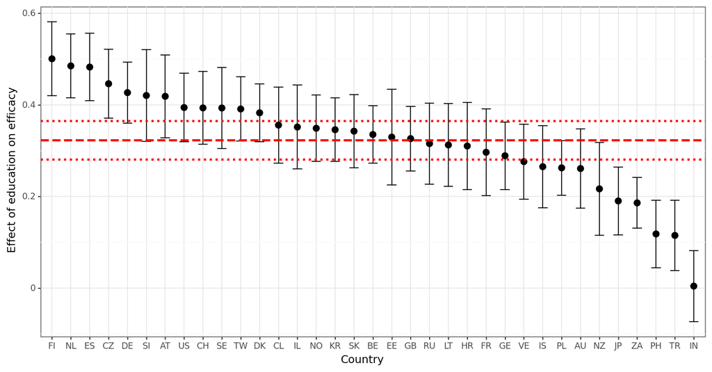

```python
re_list = list(mlm_2.random_effects.values())
se_list = list(mlm_2.random_effects_cov.values())
cnt_list = list(mlm_2.random_effects.keys())
vec_re = []
vec_se = []
vec_cnt = []
for i in range(len(re_list)):
     vec_re.append(re_list[:][i][1])
     vec_cnt.append(cnt_list[:][i])
     vec_se.append(se_list[:][i]['educCWC'][1] ** (1/2))

mlm_out = pd.DataFrame({'term': vec_cnt, 'coef': vec_re, 'se': vec_se})
# To these REs, add the value of the intercept and compute CIs
mlm_out['coef'] = mlm_out['coef'] + mlm_2.fe_params['educCWC']
mlm_out['ci_lo'] = mlm_out['coef'] - 1.96 * mlm_out['se']
mlm_out['ci_hi'] = mlm_out['coef'] + 1.96 * mlm_out['se']
mlm_out = mlm_out.drop('se', axis = 1)

(
     ggplot(mlm_out) +
     geom_point(aes(x = "reorder(term, -coef)",
                    y = "coef"),
                size = 3) +
     geom_errorbar(aes(x = "reorder(term, -coef)",
                       ymin = "ci_lo",
                       ymax = "ci_hi")) +
     geom_hline(yintercept = mlm_2.fe_params['educCWC'],
                size = 1.25,
                color = "red",
                linetype = "dashed") +
     geom_hline(yintercept = mlm_2.fe_params['educCWC'] -\
                         1.96 * mlm_2.bse_fe['educCWC'],
                size = 1.25,
                color = "red",
                linetype = "dotted") +
     geom_hline(yintercept = mlm_2.fe_params['educCWC'] +\
                         1.96 * mlm_2.bse_fe['educCWC'],
                size = 1.25,
                color = "red",
                linetype = "dotted") +
     labs(x = "Country",
          y = "Effect of education on efficacy") +
     theme_bw() +
     theme(figure_size = (12, 6),
           legend_position = "top")
)
```

The red dashed line denotes the overall slope, while the dots and whiskers plot the group slopes. You could easily generate a similar plot for the varying intercepts, if you wanted to see what is going on.

# 4 Cross-level interactions

Extend the specification by adding a predictor for the varying slope of education. The substantive implication of this is that you are now testing a hypothesis: that there is a systematic association between the magnitude of the effect of education on political efficacy, and the level of (perceived) corruption in the country.

## 4.1 Initial specification

```python
mlm_3 = sm1.mixedlm("poleff ~ age10CWC + femCWC + educCWC + urbanCWC +\
                         inc2CWC + inc3CWC + inc4CWC + cpiCGM + educCWC * cpiCGM",
                    df_issp,
                    groups = df_issp["cnt"],
                    re_formula = "~educCWC").fit()

print(mlm_3.summary())
```

```
             Mixed Linear Model Regression Results
===============================================================
Model:              MixedLM   Dependent Variable:   poleff
No. Observations:   37628     Method:               REML
No. Groups:         35        Scale:                0.4706
Min. group size:    517       Log-Likelihood:       -39360.9473
Max. group size:    2202      Converged:            Yes
Mean group size:    1075.1
---------------------------------------------------------------
                    Coef.  Std.Err.    z    P>|z| [0.025 0.975]
---------------------------------------------------------------
Intercept            2.963    0.045  65.506 0.000  2.874  3.052
age10CWC             0.122    0.007  16.243 0.000  0.107  0.136
femCWC              -0.121    0.007 -17.002 0.000 -0.135 -0.107
educCWC              0.322    0.019  16.573 0.000  0.284  0.361
urbanCWC             0.044    0.007   6.166 0.000  0.030  0.059
inc2CWC              0.057    0.009   6.507 0.000  0.040  0.074
inc3CWC              0.114    0.009  12.713 0.000  0.096  0.131
inc4CWC              0.219    0.009  23.530 0.000  0.201  0.237
cpiCGM               0.294    0.090   3.255 0.001  0.117  0.472
educCWC:cpiCGM       0.107    0.038   2.778 0.005  0.031  0.182
Group Var            0.071    0.026
Group x educCWC Cov -0.007    0.008
educCWC Var          0.011    0.005
===============================================================
```

## 4.2 Present interaction effect

Currently, presenting such interaction effects is a more code-demanding task, as in involves manually specifying a range for the moderator variable, constructing a new data set, obtaining predicted values and uncertainty for them, and then plotting these quantities.

```python
# As we're dealing with centered variables, their means are all 0 (or very nearly 0)
df_input = pd.DataFrame(np.array(np.meshgrid(np.linspace(-3, 2, 11),
                                             np.linspace(-1.2, 0.6, 4))).\
                         reshape(2, 44).T)

df_input = df_input.rename({0: 'educCWC', 1: 'cpiCGM'}, axis = 1)
df_input[['age10CWC', 'femCWC', 'urbanCWC', 'inc2CWC',
          'inc3CWC', 'inc4CWC']] = 0

# Generate predictions based on on fixed effects mean structure
df_pred = mlm_3.predict(exog = df_input)

df_pred = pd.concat([df_input[['educCWC', 'cpiCGM']], df_pred],
                    axis = 1).rename({0: 'pred'}, axis = 1)
```

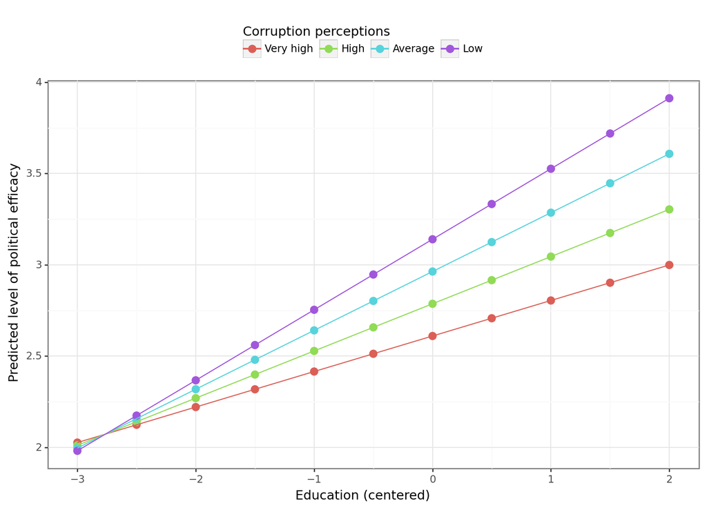

```python
df_pred['cpiCGM'] = df_pred['cpiCGM'].astype("category")

(
     ggplot(df_pred,
            aes(x = "educCWC",
                y = "pred",
                color = "cpiCGM",
                group = "cpiCGM")) +
     geom_point(size = 3) +
     geom_line() +
     labs(x = "Education (centered)",
          y = "Predicted level of political efficacy") +
     scale_color_discrete(name = "Corruption perceptions",
                          breaks = [-1.2, -0.6, 0, 0.6],
                          labels = ["Very high", "High",
                                    "Average", "Low"]) +
     theme_bw() +
     theme(figure_size = (10, 6),
           legend_position = "top")
)
```

Unfortunately, there is currently no implementation in **Python** that I know of that would also allow us to obtain estimates of uncertainty for these predictions. Therefore, we stop here with this tutorial.

# 5 Package versions

Package versions used in this script.

1. `ipykernel` 6.21.2
2. `ipython` 8.10.0
3. `jupyter_client` 8.0.3
4. `jupyter_core` 5.2.0
5. `matplotlib` 3.6.3
6. `matplotlib-inline` 0.1.6
7. `numpy` 1.24.2
8. `pandas` 1.5.3
9. `plotnine` 0.10.1
10. `pyreadr` 0.4.7
11. `scipy` 1.10.0
12. `stargazer` 0.0.5
13. `statsmodels` 0.13.5